# What Influences Varying Trip Durations in Ford GoBike System?

## by Ezekiel Okato

## Investigation Overview

Focus of this investigation is on varying duration of trips. Key insights are: the distribution of the trip duration, days of week with longer trip duration and categories of members who took longer trips.

## Dataset Overview

The dataset contains information of individual rides made in a bike-sharing system covering the greater San Francisco Bay area. There are 183412 rides and 16 features in the dataset. Wrangling has been undertaken in order for exploratory analysis to be done.

## Distribution of Trip Duration

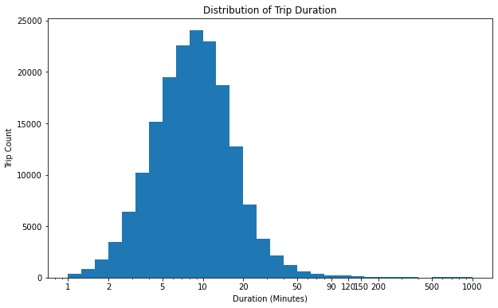

## Influence of Day of Week on Trip duration

Saturday and Sunday have the least trip counts compared to the other days of the week. However, the average duration of trips (approximately 14 minutes) on Saturday and Sunday is longer than the duration of trips taken on the remaining days.

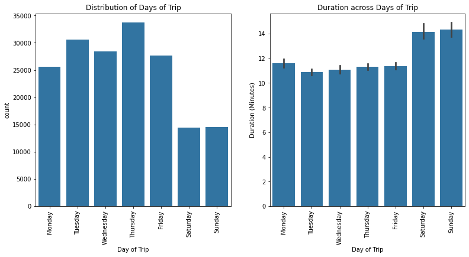

## Influence of Gender, Users and Bike Sharing on Trip Duration

There are significantly more subscribers than customers across all genders. Moreover, there are more members who prefer not to share the bikes during trips. When these variable are analysed alongside trip duration, it is seen that longer trips are taken by:

- customer users
- *other* gender
- members who do not share bikes during the trip.

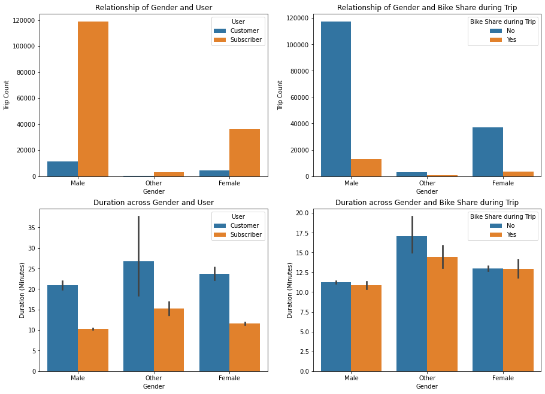